# Gene Annotation : GTEx

Kushal K Dey

July 5, 2015

## Overview

In this script, we give the gene annotations of the genes that seem to vary greatly between the clusters we get. This would be indicative of the markers that are driving the different clusters. If we can find that for a cluster which is mainly represented in a particular tissue type, if the genes significantly differentially expressed in that cluster are indeed related to the tissue in terms of its annotation, then we can say that the clustering makes biological sense.

## KL divergence scheme

```r
topics_theta <- data.frame(fread("../external_data/GTEX_V6/admix_out_GTEX_V6/theta_cis_genes_0_1_2.txt"))[,-1];
sqrt_zscore <- t(apply(topics_theta, 1, function(x)
                                      {
                                          y=sqrt(x);
                                          return((y-mean(y))/sd(y));
                                      }))

log_zscore <- t(apply(topics_theta, 1, function(x)
                                      {
                                          y=log((x)/(1-x));
                                          return((y-mean(y))/sd(y));
                                      }))
K=dim(topics_theta)[2];

KL_score_poisson <- lapply(1:K, function(n)
                                {
                                    out <- t(apply(topics_theta, 1, function(x)
                                                                    {
                                                                      y=x[n] *log(x[n]/x) + x - x[n];
                                                                      return(y)
                                                                     }));
                                    return(out)
                                })

KL_score_bernoulli <- lapply(1:K, function(n)
                                {
                                    out <- t(apply(topics_theta, 1, function(x)
                                                                    {
                                                                      y=x[n] *log(x[n]/x) + (1 - x[n])*log((1-x[n])/(1-x));
                                                                      return(y)
                                                                     }));
                                    return(out)
                                })
```

We used four divergence conditions

- Square root z - transform
- Log z- transform
- Bernoulli K-L divergence
- Poisson K-L divergence

Out of these conditions, Square root z- transform and Log z-transform gave close results. On the other hand, Bernoulli K-L divergence and Poisson K-L divergence gave practically identical results (almost). So, we focused on the Poisson K-L divergence and the Square root Z- transform instead.

## Gene Annotations (mygene package)

Use **mygene** R package to get information about all the cis- genes used in the GTEx data. It creates a database of the cis genes with summary level information.

[output not shown]

```
## Finished
## Pass returnall=TRUE to return lists of duplicate or missing query terms.
```

[figure not shown]

## Structure plot (K=15)

```r
omega <- data.frame(fread("../external_data/GTEX_V6/admix_out_GTEX_V6/omega_cis_genes_0_1_2.txt"))[,-1];
```

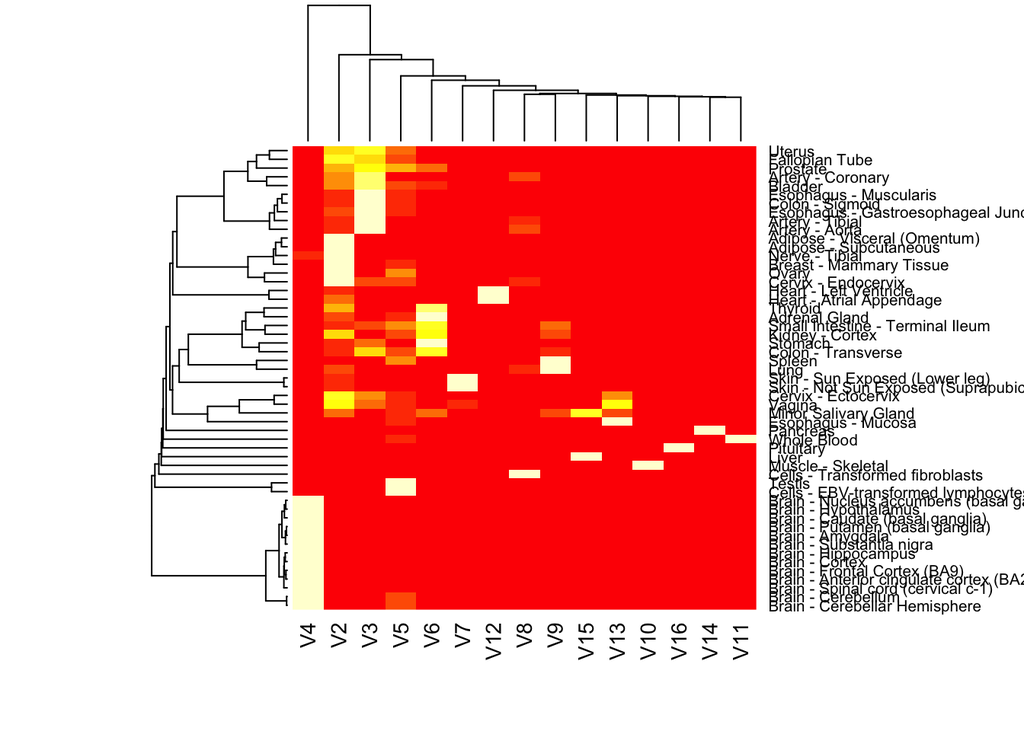

```r
samples_id=read.table("../external_data/GTEX_V6/samples_id.txt")[,3];
docweights_per_tissue_mean <- apply(omega,2,function(x) tapply(x,samples_id,mean));

ordering=heatmap(docweights_per_tissue_mean)$rowInd;
```

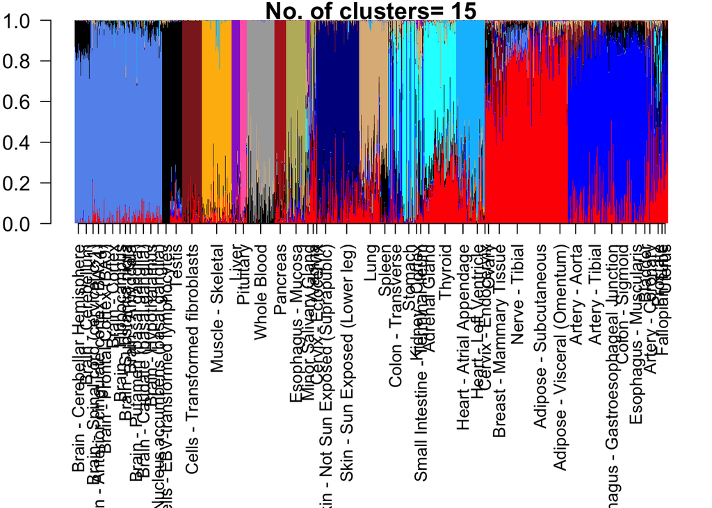

```r
unique_samples_id_ordered = unique(samples_id)[ordering];
clus_ordered =unlist(lapply(1:53, function(x) which(samples_id == unique_samples_id_ordered[x])));
samples_id_ordered = samples_id[clus_ordered];

docweights_ordering = omega[clus_ordered,];

par(mar=c(14,2.5,1,1))
barplot(t(docweights_ordering),col=color[1:K],axisnames=F,space=0,border=NA,main=paste("No. of clusters=",K),las=1,ylim=c(0,1),cex.axis=1.2,cex.main=1.4)

labels = match(unique(samples_id_ordered), samples_id_ordered);
#abline(v=labels)

labels_low=labels;
labels_up=c(labels[2:length(labels)],dim(docweights_ordering)[1]);
mid_point=labels_low +0.5*(labels_up-labels_low);
axis(1,at=mid_point, unique(samples_id_ordered),las=2);
```

## Color bars of clusters

The colors of the bars corresponding to different cluster numbers are as follows (bars arranged in sequence of the cluster number)

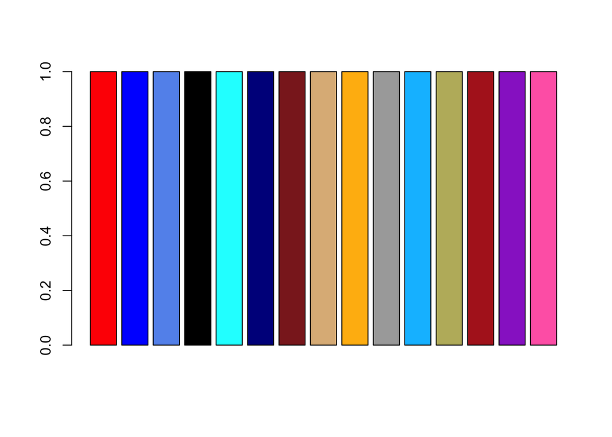

```r
barplot(rep(1,15),col=color[1:15])
```

## Gene summaries individual clusters

### red cluster (cluster 1)

```
##  [1] "ENSG00000170323" "ENSG00000189058" "ENSG00000158887"
##  [4] "ENSG00000211445" "ENSG00000166819" "ENSG00000187288"
##  [7] "ENSG00000109099" "ENSG00000079435" "ENSG00000165507"
## [10] "ENSG00000169710"
```

```
## [[1]]
##                                        name           query X_id
## 367 fatty acid binding protein 4, adipocyte ENSG00000170323 2167
##                                                                                                                                                                                                                                                                                                          …
## 367 FABP4 encodes the fatty acid binding protein found in adipocytes.  Fatty acid binding proteins are a family of small, highly conserved, cytoplasmic proteins that bind long-chain fatty acids and other hydrophobic ligands. It is thought that FABPs roles include fatty acid uptake, transport, and…
##     notfound
## 367       NA
##
## [[2]]
##                 name           query X_id
## 132 apolipoprotein D ENSG00000189058  347
##                                                                                                                                                                                                                                                                                                          …
## 132 This gene encodes a component of high density lipoprotein that has no marked similarity to other apolipoprotein sequences. It has a high degree of homology to plasma retinol-binding protein and other members of the alpha 2 microglobulin protein superfamily of carrier proteins, also known as l…
##     notfound
## 132       NA
##
## [[3]]
##                    name           query X_id
## 961 myelin protein zero ENSG00000158887 4359
##                                                                                                                                                                                               summary
## 961 This gene encodes a major structural protein of peripheral myelin. Mutations in this gene result in the autosomal dominant form of Charcot-Marie-Tooth disease type 1 and other polyneuropathies.
##     notfound
## 961       NA
##
## [[4]]
##                        name           query X_id
## 36 glutathione peroxidase 3 ENSG00000211445 2878
##                                                                                                                                                                                                                                                                                                          …
## 36 This gene product belongs to the glutathione peroxidase family, which functions in the detoxification of hydrogen peroxide. It contains a selenocysteine (Sec) residue at its active site. The selenocysteine is encoded by the UGA codon, which normally signals translation termination. The 3' UTR …
##    notfound
## 36       NA
##
## [[5]]
##             name           query X_id
## 1447 perilipin 1 ENSG00000166819 5346
##                                                                                                                                                                                                                                                                                                          …
## 1447 The protein encoded by this gene coats lipid storage droplets in adipocytes, thereby protecting them until they can be broken down by hormone-sensitive lipase. The encoded protein is the major cAMP-dependent protein kinase substrate in adipocytes and, when unphosphorylated, may play a role i…
##      notfound
## 1447       NA
##
```

[output cut: 24 more lines]

```
## [[9]]
##                                    name           query  X_id
## 331 chromosome 10 open reading frame 10 ENSG00000165507 11067
##                                                                                                                                                                                                                                                                                                          …
## 331 The expression of this gene is induced by fasting as well as by progesterone. The protein encoded by this gene contains a t-synaptosome-associated protein receptor (SNARE) coiled-coil homology domain and a peroxisomal targeting signal. Production of the encoded protein leads to phosphorylatio…
##     notfound
## 331       NA
##
## [[10]]
##                    name           query X_id
## 230 fatty acid synthase ENSG00000169710 2194
##                                                                                                                                                                                                                                                                                                          …
## 230 The enzyme encoded by this gene is a multifunctional protein. Its main function is to catalyze the synthesis of palmitate from acetyl-CoA and malonyl-CoA, in the presence of NADPH, into long-chain saturated fatty acids. In some cancer cell lines, this protein has been found to be fused with e…
##     notfound
## 230       NA
```

```
## [[1]]
##                                        name           query X_id
## 367 fatty acid binding protein 4, adipocyte ENSG00000170323 2167
##                                                                                                                                                                                                                                                                                                          …
## 367 FABP4 encodes the fatty acid binding protein found in adipocytes.  Fatty acid binding proteins are a family of small, highly conserved, cytoplasmic proteins that bind long-chain fatty acids and other hydrophobic ligands. It is thought that FABPs roles include fatty acid uptake, transport, and…
##     notfound
## 367       NA
##
## [[2]]
##                 name           query X_id
## 132 apolipoprotein D ENSG00000189058  347
##                                                                                                                                                                                                                                                                                                          …
## 132 This gene encodes a component of high density lipoprotein that has no marked similarity to other apolipoprotein sequences. It has a high degree of homology to plasma retinol-binding protein and other members of the alpha 2 microglobulin protein superfamily of carrier proteins, also known as l…
##     notfound
## 132       NA
##
## [[3]]
##                    name           query X_id
## 961 myelin protein zero ENSG00000158887 4359
##                                                                                                                                                                                               summary
## 961 This gene encodes a major structural protein of peripheral myelin. Mutations in this gene result in the autosomal dominant form of Charcot-Marie-Tooth disease type 1 and other polyneuropathies.
##     notfound
## 961       NA
##
## [[4]]
##                        name           query X_id
## 36 glutathione peroxidase 3 ENSG00000211445 2878
##                                                                                                                                                                                                                                                                                                          …
## 36 This gene product belongs to the glutathione peroxidase family, which functions in the detoxification of hydrogen peroxide. It contains a selenocysteine (Sec) residue at its active site. The selenocysteine is encoded by the UGA codon, which normally signals translation termination. The 3' UTR …
##    notfound
## 36       NA
##
## [[5]]
##             name           query X_id
## 1447 perilipin 1 ENSG00000166819 5346
##                                                                                                                                                                                                                                                                                                          …
## 1447 The protein encoded by this gene coats lipid storage droplets in adipocytes, thereby protecting them until they can be broken down by hormone-sensitive lipase. The encoded protein is the major cAMP-dependent protein kinase substrate in adipocytes and, when unphosphorylated, may play a role i…
##      notfound
## 1447       NA
##
```

[output cut: 24 more lines]

```
## [[9]]
##                                    name           query  X_id
## 331 chromosome 10 open reading frame 10 ENSG00000165507 11067
##                                                                                                                                                                                                                                                                                                          …
## 331 The expression of this gene is induced by fasting as well as by progesterone. The protein encoded by this gene contains a t-synaptosome-associated protein receptor (SNARE) coiled-coil homology domain and a peroxisomal targeting signal. Production of the encoded protein leads to phosphorylatio…
##     notfound
## 331       NA
##
## [[10]]
##                    name           query X_id
## 230 fatty acid synthase ENSG00000169710 2194
##                                                                                                                                                                                                                                                                                                          …
## 230 The enzyme encoded by this gene is a multifunctional protein. Its main function is to catalyze the synthesis of palmitate from acetyl-CoA and malonyl-CoA, in the presence of NADPH, into long-chain saturated fatty acids. In some cancer cell lines, this protein has been found to be fused with e…
##     notfound
## 230       NA
```

### blue cluster (cluster 2)

```
##  [1] "ENSG00000133392" "ENSG00000107796" "ENSG00000163017"
##  [4] "ENSG00000149591" "ENSG00000101335" "ENSG00000180139"
##  [7] "ENSG00000130176" "ENSG00000159176" "ENSG00000163431"
## [10] "ENSG00000259716"
```

```
## [[1]]
##                                     name           query X_id
## 16 myosin, heavy chain 11, smooth muscle ENSG00000133392 4629
##                                                                                                                                                                                                                                                                                                          …
## 16 The protein encoded by this gene is a smooth muscle myosin belonging to the myosin heavy chain family. The gene product is a subunit of a hexameric protein that consists of two heavy chain subunits and two pairs of non-identical light chain subunits. It functions as a major contractile protein…
##    notfound
## 16       NA
##
## [[2]]
##                                    name           query X_id
## 40 actin, alpha 2, smooth muscle, aorta ENSG00000107796   59
##                                                                                                                                                                                                                                                                                                          …
## 40 The protein encoded by this gene belongs to the actin family of proteins, which are highly conserved proteins that play a role in cell motility, structure and integrity. Alpha, beta and gamma actin isoforms have been identified, with alpha actins being a major constituent of the contractile ap…
##    notfound
## 40       NA
##
## [[3]]
##                                      name           query X_id
## 90 actin, gamma 2, smooth muscle, enteric ENSG00000163017   72
##                                                                                                                                                                                                                                                                                                          …
## 90 Actins are highly conserved proteins that are involved in various types of cell motility and in the maintenance of the cytoskeleton. Three types of actins, alpha, beta and gamma, have been identified in vertebrates. Alpha actins are found in muscle tissues and are a major constituent of the co…
##    notfound
## 90       NA
##
## [[4]]
##          name           query X_id
## 83 transgelin ENSG00000149591 6876
##                                                                                                                                                                                                                                                                                                          …
## 83 The protein encoded by this gene is a transformation and shape-change sensitive actin cross-linking/gelling protein found in fibroblasts and smooth muscle. Its expression is down-regulated in many cell lines, and this down-regulation may be an early and sensitive marker for the onset of transf…
##    notfound
## 83       NA
##
## [[5]]
##                                 name           query  X_id
## 41 myosin, light chain 9, regulatory ENSG00000101335 10398
##                                                                                                                                                                                                                                                                                                          …
## 41 Myosin, a structural component of muscle, consists of two heavy chains and four light chains. The protein encoded by this gene is a myosin light chain that may regulate muscle contraction by modulating the ATPase activity of myosin heads. The encoded protein binds calcium and is activated by m…
##    notfound
## 41       NA
##
```

[output cut: 12 more lines]

```
## 92 This gene encodes a member of the cysteine-rich protein (CSRP) family. This gene family includes a group of LIM domain proteins, which may be involved in regulatory processes important for development and cellular differentiation. The LIM/double zinc-finger motif found in this gene product occ…
##    notfound
## 92       NA
##
## [[9]]
##                            name           query  X_id
## 255 leiomodin 1 (smooth muscle) ENSG00000163431 25802
##                                                                                                                                                                                                                                                                                                          …
## 255 The leiomodin 1 protein has a putative membrane-spanning region and 2 types of tandemly repeated blocks.  The transcript is expressed in all tissues tested, with the highest levels in thyroid, eye muscle, skeletal muscle, and ovary. Increased expression of leiomodin 1 may be linked to Graves'…
##     notfound
## 255       NA
##
## [[10]]
##    name           query X_id summary notfound
## 93 <NA> ENSG00000259716 <NA>    <NA>     TRUE
```

```
## [[1]]
##                                     name           query X_id
## 16 myosin, heavy chain 11, smooth muscle ENSG00000133392 4629
##                                                                                                                                                                                                                                                                                                          …
## 16 The protein encoded by this gene is a smooth muscle myosin belonging to the myosin heavy chain family. The gene product is a subunit of a hexameric protein that consists of two heavy chain subunits and two pairs of non-identical light chain subunits. It functions as a major contractile protein…
##    notfound
## 16       NA
##
## [[2]]
##                                    name           query X_id
## 40 actin, alpha 2, smooth muscle, aorta ENSG00000107796   59
##                                                                                                                                                                                                                                                                                                          …
## 40 The protein encoded by this gene belongs to the actin family of proteins, which are highly conserved proteins that play a role in cell motility, structure and integrity. Alpha, beta and gamma actin isoforms have been identified, with alpha actins being a major constituent of the contractile ap…
##    notfound
## 40       NA
##
## [[3]]
##                                      name           query X_id
## 90 actin, gamma 2, smooth muscle, enteric ENSG00000163017   72
##                                                                                                                                                                                                                                                                                                          …
## 90 Actins are highly conserved proteins that are involved in various types of cell motility and in the maintenance of the cytoskeleton. Three types of actins, alpha, beta and gamma, have been identified in vertebrates. Alpha actins are found in muscle tissues and are a major constituent of the co…
##    notfound
## 90       NA
##
## [[4]]
##          name           query X_id
## 83 transgelin ENSG00000149591 6876
##                                                                                                                                                                                                                                                                                                          …
## 83 The protein encoded by this gene is a transformation and shape-change sensitive actin cross-linking/gelling protein found in fibroblasts and smooth muscle. Its expression is down-regulated in many cell lines, and this down-regulation may be an early and sensitive marker for the onset of transf…
##    notfound
## 83       NA
##
## [[5]]
##                                 name           query  X_id
## 41 myosin, light chain 9, regulatory ENSG00000101335 10398
##                                                                                                                                                                                                                                                                                                          …
## 41 Myosin, a structural component of muscle, consists of two heavy chains and four light chains. The protein encoded by this gene is a myosin light chain that may regulate muscle contraction by modulating the ATPase activity of myosin heads. The encoded protein binds calcium and is activated by m…
##    notfound
## 41       NA
##
```

[output cut: 12 more lines]

```
## 92 This gene encodes a member of the cysteine-rich protein (CSRP) family. This gene family includes a group of LIM domain proteins, which may be involved in regulatory processes important for development and cellular differentiation. The LIM/double zinc-finger motif found in this gene product occ…
##    notfound
## 92       NA
##
## [[9]]
##                            name           query  X_id
## 255 leiomodin 1 (smooth muscle) ENSG00000163431 25802
##                                                                                                                                                                                                                                                                                                          …
## 255 The leiomodin 1 protein has a putative membrane-spanning region and 2 types of tandemly repeated blocks.  The transcript is expressed in all tissues tested, with the highest levels in thyroid, eye muscle, skeletal muscle, and ovary. Increased expression of leiomodin 1 may be linked to Graves'…
##     notfound
## 255       NA
##
## [[10]]
##    name           query X_id summary notfound
## 93 <NA> ENSG00000259716 <NA>    <NA>     TRUE
```

### shallow blue cluster (cluster 3)

```
##  [1] "ENSG00000197971" "ENSG00000131095" "ENSG00000266844"
##  [4] "ENSG00000180354" "ENSG00000155980" "ENSG00000087250"
##  [7] "ENSG00000132639" "ENSG00000160781" "ENSG00000104833"
## [10] "ENSG00000168309"
```

```
## [[1]]
##                    name           query X_id
## 14 myelin basic protein ENSG00000197971 4155
##                                                                                                                                                                                                                                                                                                          …
## 14 The protein encoded by the classic MBP gene is a major constituent of the myelin sheath of oligodendrocytes and Schwann cells in the nervous system. However, MBP-related transcripts are also present in the bone marrow and the immune system. These mRNAs arise from the long MBP gene (otherwise c…
##    notfound
## 14       NA
##
## [[2]]
##                               name           query X_id
## 51 glial fibrillary acidic protein ENSG00000131095 2670
##                                                                                                                                                                                                                                                                                                          …
## 51 This gene encodes one of the major intermediate filament proteins of mature astrocytes. It is used as a marker to distinguish astrocytes from other glial cells during development. Mutations in this gene cause Alexander disease, a rare disorder of astrocytes in the central nervous system. Alter…
##    notfound
## 51       NA
##
## [[3]]
##     name           query            X_id summary notfound
## 164 <NA> ENSG00000266844 ENSG00000266844    <NA>       NA
##
## [[4]]
##                                                                       name
## 257 maturin, neural progenitor differentiation regulator homolog (Xenopus)
##               query   X_id summary notfound
## 257 ENSG00000180354 222166    <NA>       NA
##
## [[5]]
##                         name           query X_id
## 525 kinesin family member 5A ENSG00000155980 3798
##                                                                                                                                                                                                                                                                        summary
## 525 This gene encodes a member of the kinesin family of proteins. Members of this family are part of a multisubunit complex that functions as a microtubule motor in intracellular organelle transport. Mutations in this gene cause autosomal dominant spastic paraplegia 10.
##     notfound
## 525       NA
##
## [[6]]
##                   name           query X_id summary notfound
## 2191 metallothionein 3 ENSG00000087250 4504    <NA>       NA
##
## [[7]]
##                                       name           query X_id
```

[output cut: 10 more lines]

```
## 1667    <NA>       NA
##
## [[9]]
##                           name           query  X_id
## 942 tubulin, beta 4A class IVa ENSG00000104833 10382
##                                                                                                                                                                                                                                                                                                          …
## 942 This gene encodes a member of the beta tubulin family. Beta tubulins are one of two core protein families (alpha and beta tubulins) that heterodimerize and assemble to form microtubules. Mutations in this gene cause hypomyelinating leukodystrophy-6 and autosomal dominant torsion dystonia-4. A…
##     notfound
## 942       NA
##
## [[10]]
##                                              name           query  X_id
## 441 family with sequence similarity 107, member A ENSG00000168309 11170
##     summary notfound
## 441    <NA>       NA
```

```
## [[1]]
##                    name           query X_id
## 14 myelin basic protein ENSG00000197971 4155
##                                                                                                                                                                                                                                                                                                          …
## 14 The protein encoded by the classic MBP gene is a major constituent of the myelin sheath of oligodendrocytes and Schwann cells in the nervous system. However, MBP-related transcripts are also present in the bone marrow and the immune system. These mRNAs arise from the long MBP gene (otherwise c…
##    notfound
## 14       NA
##
## [[2]]
##                               name           query X_id
## 51 glial fibrillary acidic protein ENSG00000131095 2670
##                                                                                                                                                                                                                                                                                                          …
## 51 This gene encodes one of the major intermediate filament proteins of mature astrocytes. It is used as a marker to distinguish astrocytes from other glial cells during development. Mutations in this gene cause Alexander disease, a rare disorder of astrocytes in the central nervous system. Alter…
##    notfound
## 51       NA
##
## [[3]]
##     name           query            X_id summary notfound
## 164 <NA> ENSG00000266844 ENSG00000266844    <NA>       NA
##
## [[4]]
##                                                                       name
## 257 maturin, neural progenitor differentiation regulator homolog (Xenopus)
##               query   X_id summary notfound
## 257 ENSG00000180354 222166    <NA>       NA
##
## [[5]]
##                         name           query X_id
## 525 kinesin family member 5A ENSG00000155980 3798
##                                                                                                                                                                                                                                                                        summary
## 525 This gene encodes a member of the kinesin family of proteins. Members of this family are part of a multisubunit complex that functions as a microtubule motor in intracellular organelle transport. Mutations in this gene cause autosomal dominant spastic paraplegia 10.
##     notfound
## 525       NA
##
## [[6]]
##                   name           query X_id summary notfound
## 2191 metallothionein 3 ENSG00000087250 4504    <NA>       NA
##
## [[7]]
##                                       name           query X_id
```

[output cut: 10 more lines]

```
## 1667    <NA>       NA
##
## [[9]]
##                           name           query  X_id
## 942 tubulin, beta 4A class IVa ENSG00000104833 10382
##                                                                                                                                                                                                                                                                                                          …
## 942 This gene encodes a member of the beta tubulin family. Beta tubulins are one of two core protein families (alpha and beta tubulins) that heterodimerize and assemble to form microtubules. Mutations in this gene cause hypomyelinating leukodystrophy-6 and autosomal dominant torsion dystonia-4. A…
##     notfound
## 942       NA
##
## [[10]]
##                                              name           query  X_id
## 441 family with sequence similarity 107, member A ENSG00000168309 11170
##     summary notfound
## 441    <NA>       NA
```

### black cluster (cluster 4)

```
##  [1] "ENSG00000122304" "ENSG00000175646" "ENSG00000010318"
##  [4] "ENSG00000163467" "ENSG00000005189" "ENSG00000111644"
##  [7] "ENSG00000219435" "ENSG00000162129" "ENSG00000105679"
## [10] "ENSG00000234883"
```

```
## [[1]]
##             name           query X_id
## 1098 protamine 2 ENSG00000122304 5620
##                                                                                                                                                                                                                                                                                                          …
## 1098 Protamines substitute for histones in the chromatin of sperm during the haploid phase of spermatogenesis, and are the major DNA-binding proteins in the nucleus of sperm in many vertebrates. They package the sperm DNA into a highly condensed complex in a volume less than 5% of a somatic cell …
##      notfound
## 1098       NA
##
## [[2]]
##             name           query X_id summary notfound
## 2574 protamine 1 ENSG00000175646 5619    <NA>       NA
##
## [[3]]
##                      name           query  X_id
## 4361 PHD finger protein 7 ENSG00000010318 51533
##                                                                                                                                                                                                                                                                                                          …
## 4361 Spermatogenesis is a complex process regulated by extracellular and intracellular factors as well as cellular interactions among interstitial cells of the testis, Sertoli cells, and germ cells. This gene is expressed in the testis in Sertoli cells but not germ cells. The protein encoded by t…
##      notfound
## 4361       NA
##
## [[4]]
## [1] name     query    X_id     summary  notfound
## <0 rows> (or 0-length row.names)
##
## [[5]]
## [1] name     query    X_id     summary  notfound
## <0 rows> (or 0-length row.names)
##
## [[6]]
## [1] name     query    X_id     summary  notfound
## <0 rows> (or 0-length row.names)
##
## [[7]]
## [1] name     query    X_id     summary  notfound
## <0 rows> (or 0-length row.names)
##
## [[8]]
## [1] name     query    X_id     summary  notfound
## <0 rows> (or 0-length row.names)
##
## [[9]]
## [1] name     query    X_id     summary  notfound
## <0 rows> (or 0-length row.names)
##
## [[10]]
## [1] name     query    X_id     summary  notfound
## <0 rows> (or 0-length row.names)
```

```
## [[1]]
##             name           query X_id
## 1098 protamine 2 ENSG00000122304 5620
##                                                                                                                                                                                                                                                                                                          …
## 1098 Protamines substitute for histones in the chromatin of sperm during the haploid phase of spermatogenesis, and are the major DNA-binding proteins in the nucleus of sperm in many vertebrates. They package the sperm DNA into a highly condensed complex in a volume less than 5% of a somatic cell …
##      notfound
## 1098       NA
##
## [[2]]
##             name           query X_id summary notfound
## 2574 protamine 1 ENSG00000175646 5619    <NA>       NA
##
## [[3]]
##                      name           query  X_id
## 4361 PHD finger protein 7 ENSG00000010318 51533
##                                                                                                                                                                                                                                                                                                          …
## 4361 Spermatogenesis is a complex process regulated by extracellular and intracellular factors as well as cellular interactions among interstitial cells of the testis, Sertoli cells, and germ cells. This gene is expressed in the testis in Sertoli cells but not germ cells. The protein encoded by t…
##      notfound
## 4361       NA
##
## [[4]]
## [1] name     query    X_id     summary  notfound
## <0 rows> (or 0-length row.names)
##
## [[5]]
## [1] name     query    X_id     summary  notfound
## <0 rows> (or 0-length row.names)
##
## [[6]]
## [1] name     query    X_id     summary  notfound
## <0 rows> (or 0-length row.names)
##
## [[7]]
## [1] name     query    X_id     summary  notfound
## <0 rows> (or 0-length row.names)
##
## [[8]]
## [1] name     query    X_id     summary  notfound
## <0 rows> (or 0-length row.names)
##
## [[9]]
## [1] name     query    X_id     summary  notfound
## <0 rows> (or 0-length row.names)
##
## [[10]]
## [1] name     query    X_id     summary  notfound
## <0 rows> (or 0-length row.names)
```

### light blue cluster (cluster 5)

```
##  [1] "ENSG00000042832" "ENSG00000182333" "ENSG00000096088"
##  [4] "ENSG00000229859" "ENSG00000160882" "ENSG00000148795"
##  [7] "ENSG00000169605" "ENSG00000115705" "ENSG00000125618"
## [10] "ENSG00000090920"
```

```
## [[1]]
##             name           query X_id
## 60 thyroglobulin ENSG00000042832 7038
##                                                                                                                                                                                                                                                                                                          …
## 60 Thyroglobulin (Tg) is a glycoprotein homodimer produced predominantly by the thryroid gland. It acts as a substrate for the synthesis of thyroxine and triiodothyronine as well as the storage of the inactive forms of thyroid hormone and iodine. Thyroglobulin is secreted from the endoplasmic ret…
##    notfound
## 60       NA
##
## [[2]]
##                name           query X_id
## 182 lipase, gastric ENSG00000182333 8513
##                                                                                                                                                                                                                                                                                                          …
## 182 This gene encodes gastric lipase, an enzyme involved in the digestion of dietary triglycerides in the gastrointestinal tract, and responsible for 30% of fat digestion processes occurring in human. It is secreted by gastric chief cells in the fundic mucosa of the stomach, and it hydrolyzes the…
##     notfound
## 182       NA
##
## [[3]]
##                            name           query X_id
## 87 progastricsin (pepsinogen C) ENSG00000096088 5225
##                                                                                                                                                                                                                                                                                                          …
## 87 This gene encodes an aspartic proteinase that belongs to the peptidase family A1. The encoded protein is a digestive enzyme that is produced in the stomach and constitutes a major component of the gastric mucosa. This protein is also secreted into the serum. This protein is synthesized as an i…
##    notfound
## 87       NA
##
## [[4]]
##                                     name           query   X_id
## 586 pepsinogen 3, group I (pepsinogen A) ENSG00000229859 643834
##                                                                                                                                                                                                                                                                                                          …
## 586 This gene encodes a protein precursor of the digestive enzyme pepsin, a member of the peptidase A1 family of endopeptidases. The encoded precursor is secreted by gastric chief cells and undergoes autocatalytic cleavage in acidic conditions to form the active enzyme, which functions in the dig…
##     notfound
## 586       NA
##
## [[5]]
##                                                       name           query
## 816 cytochrome P450, family 11, subfamily B, polypeptide 1 ENSG00000160882
##     X_id
## 816 1584
##                                                                                                                                                                                                                                                                                                          …
## 816 This gene encodes a member of the cytochrome P450 superfamily of enzymes. The cytochrome P450 proteins are monooxygenases which catalyze many reactions involved in drug metabolism and synthesis of cholesterol, steroids and other lipids. This protein localizes to the mitochondrial inner membra…
##     notfound
```

[output cut: 24 more lines]

```
## 988 This gene encodes a membrane-bound glycoprotein. The encoded protein acts as an enzyme and plays a central role in thyroid gland function. The protein functions in the iodination of tyrosine residues in thyroglobulin and phenoxy-ester formation between pairs of iodinated tyrosines to generate…
##     notfound
## 988       NA
##
## [[9]]
##              name           query X_id
## 2790 paired box 8 ENSG00000125618 7849
##                                                                                                                                                                                                                                                                                                          …
## 2790 This gene encodes a member of the paired box (PAX) family of transcription factors. Members of this gene family typically encode proteins that contain a paired box domain, an octapeptide, and a paired-type homeodomain. This nuclear protein is involved in thyroid follicular cell development a…
##      notfound
## 2790       NA
##
## [[10]]
##      name           query X_id summary notfound
## 1126 <NA> ENSG00000090920 <NA>    <NA>     TRUE
```

```
## [[1]]
##             name           query X_id
## 60 thyroglobulin ENSG00000042832 7038
##                                                                                                                                                                                                                                                                                                          …
## 60 Thyroglobulin (Tg) is a glycoprotein homodimer produced predominantly by the thryroid gland. It acts as a substrate for the synthesis of thyroxine and triiodothyronine as well as the storage of the inactive forms of thyroid hormone and iodine. Thyroglobulin is secreted from the endoplasmic ret…
##    notfound
## 60       NA
##
## [[2]]
##                name           query X_id
## 182 lipase, gastric ENSG00000182333 8513
##                                                                                                                                                                                                                                                                                                          …
## 182 This gene encodes gastric lipase, an enzyme involved in the digestion of dietary triglycerides in the gastrointestinal tract, and responsible for 30% of fat digestion processes occurring in human. It is secreted by gastric chief cells in the fundic mucosa of the stomach, and it hydrolyzes the…
##     notfound
## 182       NA
##
## [[3]]
##                            name           query X_id
## 87 progastricsin (pepsinogen C) ENSG00000096088 5225
##                                                                                                                                                                                                                                                                                                          …
## 87 This gene encodes an aspartic proteinase that belongs to the peptidase family A1. The encoded protein is a digestive enzyme that is produced in the stomach and constitutes a major component of the gastric mucosa. This protein is also secreted into the serum. This protein is synthesized as an i…
##    notfound
## 87       NA
##
## [[4]]
##                                     name           query   X_id
## 586 pepsinogen 3, group I (pepsinogen A) ENSG00000229859 643834
##                                                                                                                                                                                                                                                                                                          …
## 586 This gene encodes a protein precursor of the digestive enzyme pepsin, a member of the peptidase A1 family of endopeptidases. The encoded precursor is secreted by gastric chief cells and undergoes autocatalytic cleavage in acidic conditions to form the active enzyme, which functions in the dig…
##     notfound
## 586       NA
##
## [[5]]
##                                                       name           query
## 816 cytochrome P450, family 11, subfamily B, polypeptide 1 ENSG00000160882
##     X_id
## 816 1584
##                                                                                                                                                                                                                                                                                                          …
## 816 This gene encodes a member of the cytochrome P450 superfamily of enzymes. The cytochrome P450 proteins are monooxygenases which catalyze many reactions involved in drug metabolism and synthesis of cholesterol, steroids and other lipids. This protein localizes to the mitochondrial inner membra…
##     notfound
```

[output cut: 24 more lines]

```
## 988 This gene encodes a membrane-bound glycoprotein. The encoded protein acts as an enzyme and plays a central role in thyroid gland function. The protein functions in the iodination of tyrosine residues in thyroglobulin and phenoxy-ester formation between pairs of iodinated tyrosines to generate…
##     notfound
## 988       NA
##
## [[9]]
##              name           query X_id
## 2790 paired box 8 ENSG00000125618 7849
##                                                                                                                                                                                                                                                                                                          …
## 2790 This gene encodes a member of the paired box (PAX) family of transcription factors. Members of this gene family typically encode proteins that contain a paired box domain, an octapeptide, and a paired-type homeodomain. This nuclear protein is involved in thyroid follicular cell development a…
##      notfound
## 2790       NA
##
## [[10]]
##      name           query X_id summary notfound
## 1126 <NA> ENSG00000090920 <NA>    <NA>     TRUE
```

### deep blue cluster (cluster 6)

```
##  [1] "ENSG00000186395" "ENSG00000167768" "ENSG00000172867"
##  [4] "ENSG00000203782" "ENSG00000186847" "ENSG00000161249"
##  [7] "ENSG00000161634" "ENSG00000178372" "ENSG00000188508"
## [10] "ENSG00000205420"
```

```
## [[1]]
##                  name           query X_id
## 39 keratin 10, type I ENSG00000186395 3858
##                                                                                                                                                                                                                                                                                                          …
## 39 This gene encodes a member of the type I (acidic) cytokeratin family, which belongs to the superfamily of intermediate filament (IF) proteins. Keratins are heteropolymeric structural proteins which form the intermediate filament. These filaments, along with actin microfilaments and microtubule…
##    notfound
## 39       NA
##
## [[2]]
##                  name           query X_id
## 50 keratin 1, type II ENSG00000167768 3848
##                                                                                                                                                                                                                                                                                                          …
## 50 The protein encoded by this gene is a member of the keratin gene family. The type II cytokeratins consist of basic or neutral proteins which are arranged in pairs of heterotypic keratin chains coexpressed during differentiation of simple and stratified epithelial tissues. This type II cytokera…
##    notfound
## 50       NA
##
## [[3]]
##                   name           query X_id
## 244 keratin 2, type II ENSG00000172867 3849
##                                                                                                                                                                                                                                                                                                          …
## 244 The protein encoded by this gene is a member of the keratin gene family. The type II cytokeratins consist of basic or neutral proteins which are arranged in pairs of heterotypic keratin chains coexpressed during differentiation of simple and stratified epithelial tissues. This type II cytoker…
##     notfound
## 244       NA
##
## [[4]]
##          name           query X_id
## 2906 loricrin ENSG00000203782 4014
##                                                                                                                                                                                                                                                                                   summary
## 2906 This gene encodes loricrin, a major protein component of the cornified cell envelope found in terminally differentiated epidermal cells. Mutations in this gene are associated with Vohwinkel's syndrome and progressive symmetric erythrokeratoderma, both inherited skin diseases.
##      notfound
## 2906       NA
##
## [[5]]
##                   name           query X_id
## 187 keratin 14, type I ENSG00000186847 3861
##                                                                                                                                                                                                                                                                                                          …
## 187 This gene encodes a member of the keratin family, the most diverse group of intermediate filaments. This gene product, a type I keratin, is usually found as a heterotetramer with two keratin 5 molecules, a type II keratin. Together they form the cytoskeleton of epithelial cells. Mutations in …
##     notfound
## 187       NA
##
```

[output cut: 18 more lines]

[output not shown]

```
## [[1]]
##                  name           query X_id
## 39 keratin 10, type I ENSG00000186395 3858
##                                                                                                                                                                                                                                                                                                          …
## 39 This gene encodes a member of the type I (acidic) cytokeratin family, which belongs to the superfamily of intermediate filament (IF) proteins. Keratins are heteropolymeric structural proteins which form the intermediate filament. These filaments, along with actin microfilaments and microtubule…
##    notfound
## 39       NA
##
## [[2]]
##                  name           query X_id
## 50 keratin 1, type II ENSG00000167768 3848
##                                                                                                                                                                                                                                                                                                          …
## 50 The protein encoded by this gene is a member of the keratin gene family. The type II cytokeratins consist of basic or neutral proteins which are arranged in pairs of heterotypic keratin chains coexpressed during differentiation of simple and stratified epithelial tissues. This type II cytokera…
##    notfound
## 50       NA
##
## [[3]]
##                   name           query X_id
## 244 keratin 2, type II ENSG00000172867 3849
##                                                                                                                                                                                                                                                                                                          …
## 244 The protein encoded by this gene is a member of the keratin gene family. The type II cytokeratins consist of basic or neutral proteins which are arranged in pairs of heterotypic keratin chains coexpressed during differentiation of simple and stratified epithelial tissues. This type II cytoker…
##     notfound
## 244       NA
##
## [[4]]
##          name           query X_id
## 2906 loricrin ENSG00000203782 4014
##                                                                                                                                                                                                                                                                                   summary
## 2906 This gene encodes loricrin, a major protein component of the cornified cell envelope found in terminally differentiated epidermal cells. Mutations in this gene are associated with Vohwinkel's syndrome and progressive symmetric erythrokeratoderma, both inherited skin diseases.
##      notfound
## 2906       NA
##
## [[5]]
##                   name           query X_id
## 187 keratin 14, type I ENSG00000186847 3861
##                                                                                                                                                                                                                                                                                                          …
## 187 This gene encodes a member of the keratin family, the most diverse group of intermediate filaments. This gene product, a type I keratin, is usually found as a heterotetramer with two keratin 5 molecules, a type II keratin. Together they form the cytoskeleton of epithelial cells. Mutations in …
##     notfound
## 187       NA
##
```

[output cut: 26 more lines]

```
## 2065 keratinocyte differentiation-associated protein ENSG00000188508
##        X_id
## 2065 388533
##                                                                                                                                                                                                                                summary
## 2065 This gene encodes a protein which may function in the regulation of keratinocyte differentiation and maintenance of stratified epithelia. Multiple transcript variants encoding different isoforms have been found for this gene.
##      notfound
## 2065       NA
##
## [[10]]
##                    name           query X_id
## 200 keratin 6A, type II ENSG00000205420 3853
##                                                                                                                                                                                                                                                                                                          …
## 200 The protein encoded by this gene is a member of the keratin gene family. The type II cytokeratins consist of basic or neutral proteins which are arranged in pairs of heterotypic keratin chains coexpressed during differentiation of simple and stratified epithelial tissues. As many as six of th…
##     notfound
## 200       NA
```

### dark brown cluster (cluster 7)

```
##  [1] "ENSG00000115414" "ENSG00000108821" "ENSG00000164692"
##  [4] "ENSG00000106366" "ENSG00000168542" "ENSG00000163359"
##  [7] "ENSG00000163661" "ENSG00000120708" "ENSG00000137801"
## [10] "ENSG00000196549"
```

```
## [[1]]
##             name           query X_id
## 10 fibronectin 1 ENSG00000115414 2335
##                                                                                                                                                                                                                                                                                                          …
## 10 This gene encodes fibronectin, a glycoprotein present in a soluble dimeric form in plasma, and in a dimeric or multimeric form at the cell surface and in extracellular matrix. Fibronectin is involved in cell adhesion and migration processes including embryogenesis, wound healing, blood coagula…
##    notfound
## 10       NA
##
## [[2]]
##                         name           query X_id
## 76 collagen, type I, alpha 1 ENSG00000108821 1277
##                                                                                                                                                                                                                                                                                                          …
## 76 This gene encodes the pro-alpha1 chains of type I collagen whose triple helix comprises two alpha1 chains and one alpha2 chain. Type I is a fibril-forming collagen found in most connective tissues and is abundant in bone, cornea, dermis and tendon. Mutations in this gene are associated with os…
##    notfound
## 76       NA
##
## [[3]]
##                         name           query X_id
## 71 collagen, type I, alpha 2 ENSG00000164692 1278
##                                                                                                                                                                                                                                                                                                          …
## 71 This gene encodes the pro-alpha2 chain of type I collagen whose triple helix comprises two alpha1 chains and one alpha2 chain. Type I is a fibril-forming collagen found in most connective tissues and is abundant in bone, cornea, dermis and tendon. Mutations in this gene are associated with ost…
##    notfound
## 71       NA
##
## [[4]]
##                                                                                              name
## 457 serpin peptidase inhibitor, clade E (nexin, plasminogen activator inhibitor type 1), member 1
##               query X_id
## 457 ENSG00000106366 5054
##                                                                                                                                                                                                                                                                                                          …
## 457 This gene encodes a member of the serine proteinase inhibitor (serpin) superfamily. This member is the principal inhibitor of tissue plasminogen activator (tPA) and urokinase (uPA), and hence is an inhibitor of fibrinolysis. Defects in this gene are the cause of plasminogen activator inhibito…
##     notfound
## 457       NA
##
## [[5]]
##                            name           query X_id
## 113 collagen, type III, alpha 1 ENSG00000168542 1281
##                                                                                                                                                                                                                                                                                                          …
## 113 This gene encodes the pro-alpha1 chains of type III collagen, a fibrillar collagen that is found in extensible connective tissues such as skin, lung, uterus, intestine and the vascular system, frequently in association with type I collagen. Mutations in this gene are associated with Ehlers-Da…
##     notfound
```

[output cut: 22 more lines]

```
## [[9]]
##                 name           query X_id
## 124 thrombospondin 1 ENSG00000137801 7057
##                                                                                                                                                                                                                                                                                                          …
## 124 The protein encoded by this gene is a subunit of a disulfide-linked homotrimeric protein. This protein is an adhesive glycoprotein that mediates cell-to-cell and cell-to-matrix interactions. This protein can bind to fibrinogen, fibronectin, laminin, type V collagen and integrins alpha-V/beta-…
##     notfound
## 124       NA
##
## [[10]]
##                                name           query X_id
## 1286 membrane metallo-endopeptidase ENSG00000196549 4311
##                                                                                                                                                                                                                                                                                                          …
## 1286 This gene encodes a common acute lymphocytic leukemia antigen that is an important cell surface marker in the diagnosis of human acute lymphocytic leukemia (ALL). This protein is present on leukemic cells of pre-B phenotype, which represent 85% of cases of ALL. This protein is not restricted…
##      notfound
## 1286       NA
```

```
## [[1]]
##             name           query X_id
## 10 fibronectin 1 ENSG00000115414 2335
##                                                                                                                                                                                                                                                                                                          …
## 10 This gene encodes fibronectin, a glycoprotein present in a soluble dimeric form in plasma, and in a dimeric or multimeric form at the cell surface and in extracellular matrix. Fibronectin is involved in cell adhesion and migration processes including embryogenesis, wound healing, blood coagula…
##    notfound
## 10       NA
##
## [[2]]
##                         name           query X_id
## 76 collagen, type I, alpha 1 ENSG00000108821 1277
##                                                                                                                                                                                                                                                                                                          …
## 76 This gene encodes the pro-alpha1 chains of type I collagen whose triple helix comprises two alpha1 chains and one alpha2 chain. Type I is a fibril-forming collagen found in most connective tissues and is abundant in bone, cornea, dermis and tendon. Mutations in this gene are associated with os…
##    notfound
## 76       NA
##
## [[3]]
##                         name           query X_id
## 71 collagen, type I, alpha 2 ENSG00000164692 1278
##                                                                                                                                                                                                                                                                                                          …
## 71 This gene encodes the pro-alpha2 chain of type I collagen whose triple helix comprises two alpha1 chains and one alpha2 chain. Type I is a fibril-forming collagen found in most connective tissues and is abundant in bone, cornea, dermis and tendon. Mutations in this gene are associated with ost…
##    notfound
## 71       NA
##
## [[4]]
##                                                                                              name
## 457 serpin peptidase inhibitor, clade E (nexin, plasminogen activator inhibitor type 1), member 1
##               query X_id
## 457 ENSG00000106366 5054
##                                                                                                                                                                                                                                                                                                          …
## 457 This gene encodes a member of the serine proteinase inhibitor (serpin) superfamily. This member is the principal inhibitor of tissue plasminogen activator (tPA) and urokinase (uPA), and hence is an inhibitor of fibrinolysis. Defects in this gene are the cause of plasminogen activator inhibito…
##     notfound
## 457       NA
##
## [[5]]
##                            name           query X_id
## 113 collagen, type III, alpha 1 ENSG00000168542 1281
##                                                                                                                                                                                                                                                                                                          …
## 113 This gene encodes the pro-alpha1 chains of type III collagen, a fibrillar collagen that is found in extensible connective tissues such as skin, lung, uterus, intestine and the vascular system, frequently in association with type I collagen. Mutations in this gene are associated with Ehlers-Da…
##     notfound
```

[output cut: 22 more lines]

```
## [[9]]
##                 name           query X_id
## 124 thrombospondin 1 ENSG00000137801 7057
##                                                                                                                                                                                                                                                                                                          …
## 124 The protein encoded by this gene is a subunit of a disulfide-linked homotrimeric protein. This protein is an adhesive glycoprotein that mediates cell-to-cell and cell-to-matrix interactions. This protein can bind to fibrinogen, fibronectin, laminin, type V collagen and integrins alpha-V/beta-…
##     notfound
## 124       NA
##
## [[10]]
##                                name           query X_id
## 1286 membrane metallo-endopeptidase ENSG00000196549 4311
##                                                                                                                                                                                                                                                                                                          …
## 1286 This gene encodes a common acute lymphocytic leukemia antigen that is an important cell surface marker in the diagnosis of human acute lymphocytic leukemia (ALL). This protein is present on leukemic cells of pre-B phenotype, which represent 85% of cases of ALL. This protein is not restricted…
##      notfound
## 1286       NA
```

### shallow yellow cluster (cluster 8)

```
##  [1] "ENSG00000168878" "ENSG00000185303" "ENSG00000122852"
##  [4] "ENSG00000168484" "ENSG00000211896" "ENSG00000175899"
##  [7] "ENSG00000211893" "ENSG00000131400" "ENSG00000163220"
## [10] "ENSG00000211897"
```

[output not shown]

```
## [[1]]
##                     name           query X_id
## 302 surfactant protein B ENSG00000168878 6439
##                                                                                                                                                                                                                                                                                                          …
## 302 This gene encodes the pulmonary-associated surfactant protein B (SPB), an amphipathic surfactant protein essential for lung function and homeostasis after birth. Pulmonary surfactant is a surface-active lipoprotein complex composed of 90% lipids and 10% proteins which include plasma proteins …
##     notfound
## 302       NA
##
## [[2]]
##                      name           query   X_id
## 619 surfactant protein A2 ENSG00000185303 729238
##                                                                                                                                                                                                                                                                                                          …
## 619 This gene is one of several genes encoding pulmonary-surfactant associated proteins (SFTPA) located on chromosome 10. Mutations in this gene and a highly similar gene located nearby, which affect the highly conserved carbohydrate recognition domain, are associated with idiopathic pulmonary fi…
##     notfound
## 619       NA
##
## [[3]]
##                      name           query   X_id
## 915 surfactant protein A1 ENSG00000122852 653509
##                                                                                                                                                                                                                                                                                                          …
## 915 This gene encodes a lung surfactant protein that is a member of a subfamily of C-type lectins called collectins. The encoded protein binds specific carbohydrate moieties found on lipids and on the surface of microorganisms. This protein plays an essential role in surfactant homeostasis and in…
##     notfound
## 915       NA
##
## [[4]]
##                     name           query X_id
## 580 surfactant protein C ENSG00000168484 6440
##                                                                                                                                                                                                                                                                                                          …
## 580 This gene encodes the pulmonary-associated surfactant protein C (SPC), an extremely hydrophobic surfactant protein essential for lung function and homeostasis after birth. Pulmonary surfactant is a surface-active lipoprotein complex composed of 90% lipids and 10% proteins which include plasma…
##     notfound
## 580       NA
##
## [[5]]
##                                                   name           query
## 414 immunoglobulin heavy constant gamma 1 (G1m marker) ENSG00000211896
##                X_id summary notfound
## 414 ENSG00000211896    <NA>       NA
##
## [[6]]
##                     name           query X_id
```

[output cut: 14 more lines]

```
## <0 rows> (or 0-length row.names)
##
## [[9]]
##                               name           query X_id
## 77 S100 calcium binding protein A9 ENSG00000163220 6280
##                                                                                                                                                                                                                                                                                                          …
## 77 The protein encoded by this gene is a member of the S100 family of proteins containing 2 EF-hand calcium-binding motifs. S100 proteins are localized in the cytoplasm and/or nucleus of a wide range of cells, and involved in the regulation of a number of cellular processes such as cell cycle pro…
##    notfound
## 77       NA
##
## [[10]]
##                                                    name           query
## 5012 immunoglobulin heavy constant gamma 3 (G3m marker) ENSG00000211897
##                 X_id summary notfound
## 5012 ENSG00000211897    <NA>       NA
```

### yellow cluster (cluster 9)

```
##  [1] "ENSG00000109061" "ENSG00000183091" "ENSG00000125414"
##  [4] "ENSG00000196091" "ENSG00000143632" "ENSG00000168530"
##  [7] "ENSG00000101470" "ENSG00000105048" "ENSG00000104879"
## [10] "ENSG00000196296"
```

```
## [[1]]
##                                              name           query X_id
## 290 myosin, heavy chain 1, skeletal muscle, adult ENSG00000109061 4619
##                                                                                                                                                                                                                                                                                                          …
## 290 Myosin is a major contractile protein which converts chemical energy into mechanical energy through the hydrolysis of ATP. Myosin is a hexameric protein composed of a pair of myosin heavy chains (MYH) and two pairs of nonidentical light chains. Myosin heavy chains are encoded by a multigene f…
##     notfound
## 290       NA
##
## [[2]]
##        name           query X_id
## 123 nebulin ENSG00000183091 4703
##                                                                                                                                                                                                                                                                                                          …
## 123 This gene encodes nebulin, a giant protein component of the cytoskeletal matrix that coexists with the thick and thin filaments within the sarcomeres of skeletal muscle. In most vertebrates, nebulin accounts for 3 to 4% of the total myofibrillar protein. The encoded protein contains approxima…
##     notfound
## 123       NA
##
## [[3]]
##                                              name           query X_id
## 425 myosin, heavy chain 2, skeletal muscle, adult ENSG00000125414 4620
##                                                                                                                                                                                                                                                                                                          …
## 425 Myosins are actin-based motor proteins that function in the generation of mechanical force in eukaryotic cells. Muscle myosins are heterohexamers composed of 2 myosin heavy chains and 2 pairs of nonidentical myosin light chains. This gene encodes a member of the class II or conventional myosi…
##     notfound
## 425       NA
##
## [[4]]
##                                    name           query X_id
## 173 myosin binding protein C, slow type ENSG00000196091 4604
##                                                                                                                                                                                                                                                                                                          …
## 173 This gene encodes a member of the myosin-binding protein C family. Myosin-binding protein C family members are myosin-associated proteins found in the cross-bridge-bearing zone (C region) of A bands in striated muscle. The encoded protein is the slow skeletal muscle isoform of myosin-binding …
##     notfound
## 173       NA
##
## [[5]]
##                               name           query X_id
## 32 actin, alpha 1, skeletal muscle ENSG00000143632   58
##                                                                                                                                                                                                                                                                                                          …
## 32 The product encoded by this gene belongs to the actin family of proteins, which are highly conserved proteins that play a role in cell motility, structure and integrity. Alpha, beta and gamma actin isoforms have been identified, with alpha actins being a major constituent of the contractile ap…
##    notfound
## 32       NA
##
```

[output cut: 26 more lines]

```
## 43 creatine kinase, muscle ENSG00000104879 1158
##                                                                                                                                                                                                                                                                                                          …
## 43 The protein encoded by this gene is a cytoplasmic enzyme involved in energy homeostasis and is an important serum marker for myocardial infarction. The encoded protein reversibly catalyzes the transfer of phosphate between ATP and various phosphogens such as creatine phosphate. It acts as a ho…
##    notfound
## 43       NA
##
## [[10]]
##                                                         name
## 838 ATPase, Ca++ transporting, cardiac muscle, fast twitch 1
##               query X_id
## 838 ENSG00000196296  487
##                                                                                                                                                                                                                                                                                                          …
## 838 This gene encodes one of the SERCA Ca(2+)-ATPases, which are intracellular pumps located in the sarcoplasmic or endoplasmic reticula of muscle cells. This enzyme catalyzes the hydrolysis of ATP coupled with the translocation of calcium from the cytosol to the sarcoplasmic reticulum lumen, and…
##     notfound
## 838       NA
```

```
## [[1]]
##                                              name           query X_id
## 290 myosin, heavy chain 1, skeletal muscle, adult ENSG00000109061 4619
##                                                                                                                                                                                                                                                                                                          …
## 290 Myosin is a major contractile protein which converts chemical energy into mechanical energy through the hydrolysis of ATP. Myosin is a hexameric protein composed of a pair of myosin heavy chains (MYH) and two pairs of nonidentical light chains. Myosin heavy chains are encoded by a multigene f…
##     notfound
## 290       NA
##
## [[2]]
##        name           query X_id
## 123 nebulin ENSG00000183091 4703
##                                                                                                                                                                                                                                                                                                          …
## 123 This gene encodes nebulin, a giant protein component of the cytoskeletal matrix that coexists with the thick and thin filaments within the sarcomeres of skeletal muscle. In most vertebrates, nebulin accounts for 3 to 4% of the total myofibrillar protein. The encoded protein contains approxima…
##     notfound
## 123       NA
##
## [[3]]
##                                              name           query X_id
## 425 myosin, heavy chain 2, skeletal muscle, adult ENSG00000125414 4620
##                                                                                                                                                                                                                                                                                                          …
## 425 Myosins are actin-based motor proteins that function in the generation of mechanical force in eukaryotic cells. Muscle myosins are heterohexamers composed of 2 myosin heavy chains and 2 pairs of nonidentical myosin light chains. This gene encodes a member of the class II or conventional myosi…
##     notfound
## 425       NA
##
## [[4]]
##                                    name           query X_id
## 173 myosin binding protein C, slow type ENSG00000196091 4604
##                                                                                                                                                                                                                                                                                                          …
## 173 This gene encodes a member of the myosin-binding protein C family. Myosin-binding protein C family members are myosin-associated proteins found in the cross-bridge-bearing zone (C region) of A bands in striated muscle. The encoded protein is the slow skeletal muscle isoform of myosin-binding …
##     notfound
## 173       NA
##
## [[5]]
##                               name           query X_id
## 32 actin, alpha 1, skeletal muscle ENSG00000143632   58
##                                                                                                                                                                                                                                                                                                          …
## 32 The product encoded by this gene belongs to the actin family of proteins, which are highly conserved proteins that play a role in cell motility, structure and integrity. Alpha, beta and gamma actin isoforms have been identified, with alpha actins being a major constituent of the contractile ap…
##    notfound
## 32       NA
##
```

[output cut: 26 more lines]

```
## 43 creatine kinase, muscle ENSG00000104879 1158
##                                                                                                                                                                                                                                                                                                          …
## 43 The protein encoded by this gene is a cytoplasmic enzyme involved in energy homeostasis and is an important serum marker for myocardial infarction. The encoded protein reversibly catalyzes the transfer of phosphate between ATP and various phosphogens such as creatine phosphate. It acts as a ho…
##    notfound
## 43       NA
##
## [[10]]
##                                                         name
## 838 ATPase, Ca++ transporting, cardiac muscle, fast twitch 1
##               query X_id
## 838 ENSG00000196296  487
##                                                                                                                                                                                                                                                                                                          …
## 838 This gene encodes one of the SERCA Ca(2+)-ATPases, which are intracellular pumps located in the sarcoplasmic or endoplasmic reticula of muscle cells. This enzyme catalyzes the hydrolysis of ATP coupled with the translocation of calcium from the cytosol to the sarcoplasmic reticulum lumen, and…
##     notfound
## 838       NA
```

### grey cluster (cluster 10)

```
##  [1] "ENSG00000244734" "ENSG00000188536" "ENSG00000206172"
##  [4] "ENSG00000119535" "ENSG00000185201" "ENSG00000188404"
##  [7] "ENSG00000162747" "ENSG00000171051" "ENSG00000163464"
## [10] "ENSG00000112303"
```

```
## [[1]]
##               name           query X_id
## 7 hemoglobin, beta ENSG00000244734 3043
##                                                                                                                                                                                                                                                                                                          …
## 7 The alpha (HBA) and beta (HBB) loci determine the structure of the 2 types of polypeptide chains in adult hemoglobin, Hb A. The normal adult hemoglobin tetramer consists of two alpha chains and two beta chains. Mutant beta globin causes sickle cell anemia. Absence of beta chain causes beta-zero…
##   notfound
## 7       NA
##
## [[2]]
##                   name           query X_id
## 11 hemoglobin, alpha 2 ENSG00000188536 3040
##                                                                                                                                                                                                                                                                                                          …
## 11 The human alpha globin gene cluster located on chromosome 16 spans about 30 kb and includes seven loci: 5'- zeta - pseudozeta - mu - pseudoalpha-1 - alpha-2 - alpha-1 - theta - 3'. The alpha-2 (HBA2) and alpha-1 (HBA1) coding sequences are identical. These genes differ slightly over the 5' unt…
##    notfound
## 11       NA
##
## [[3]]
##                   name           query X_id
## 49 hemoglobin, alpha 1 ENSG00000206172 3039
##                                                                                                                                                                                                                                                                                                          …
## 49 The human alpha globin gene cluster located on chromosome 16 spans about 30 kb and includes seven loci: 5'- zeta - pseudozeta - mu - pseudoalpha-1 - alpha-2 - alpha-1 - theta - 3'. The alpha-2 (HBA2) and alpha-1 (HBA1) coding sequences are identical. These genes differ slightly over the 5' unt…
##    notfound
## 49       NA
##
## [[4]]
##                                                   name           query
## 422 colony stimulating factor 3 receptor (granulocyte) ENSG00000119535
##     X_id
## 422 1441
##                                                                                                                                                                                                                                                                                                          …
## 422 The protein encoded by this gene is the receptor for colony stimulating factor 3, a cytokine that controls the production, differentiation, and function of granulocytes. The encoded protein, which is a member of the family of cytokine receptors, may also function in some cell surface adhesion…
##     notfound
## 422       NA
##
## [[5]]
##                                           name           query  X_id
## 306 interferon induced transmembrane protein 2 ENSG00000185201 10581
##     summary notfound
## 306    <NA>       NA
##
```

[output cut: 26 more lines]

```
## [[9]]
##                                    name           query X_id
## 3712 chemokine (C-X-C motif) receptor 1 ENSG00000163464 3577
##                                                                                                                                                                                                                                                                                                          …
## 3712 The protein encoded by this gene is a member of the G-protein-coupled receptor family. This protein is a receptor for interleukin 8 (IL8). It binds to IL8 with high affinity, and transduces the signal through a G-protein activated second messenger system. Knockout studies in mice suggested t…
##      notfound
## 3712       NA
##
## [[10]]
##         name           query X_id
## 2863 vanin 2 ENSG00000112303 8875
##                                                                                                                                                                                                                                                                                                          …
## 2863 This gene product is a member of the Vanin family of proteins that share extensive sequence similarity with each other, and also with biotinidase. The family includes secreted and membrane-associated proteins, a few of which have been reported to participate in hematopoietic cell trafficking…
##      notfound
## 2863       NA
```

```
## [[1]]
##               name           query X_id
## 7 hemoglobin, beta ENSG00000244734 3043
##                                                                                                                                                                                                                                                                                                          …
## 7 The alpha (HBA) and beta (HBB) loci determine the structure of the 2 types of polypeptide chains in adult hemoglobin, Hb A. The normal adult hemoglobin tetramer consists of two alpha chains and two beta chains. Mutant beta globin causes sickle cell anemia. Absence of beta chain causes beta-zero…
##   notfound
## 7       NA
##
## [[2]]
##                   name           query X_id
## 11 hemoglobin, alpha 2 ENSG00000188536 3040
##                                                                                                                                                                                                                                                                                                          …
## 11 The human alpha globin gene cluster located on chromosome 16 spans about 30 kb and includes seven loci: 5'- zeta - pseudozeta - mu - pseudoalpha-1 - alpha-2 - alpha-1 - theta - 3'. The alpha-2 (HBA2) and alpha-1 (HBA1) coding sequences are identical. These genes differ slightly over the 5' unt…
##    notfound
## 11       NA
##
## [[3]]
##                   name           query X_id
## 49 hemoglobin, alpha 1 ENSG00000206172 3039
##                                                                                                                                                                                                                                                                                                          …
## 49 The human alpha globin gene cluster located on chromosome 16 spans about 30 kb and includes seven loci: 5'- zeta - pseudozeta - mu - pseudoalpha-1 - alpha-2 - alpha-1 - theta - 3'. The alpha-2 (HBA2) and alpha-1 (HBA1) coding sequences are identical. These genes differ slightly over the 5' unt…
##    notfound
## 49       NA
##
## [[4]]
##                                                   name           query
## 422 colony stimulating factor 3 receptor (granulocyte) ENSG00000119535
##     X_id
## 422 1441
##                                                                                                                                                                                                                                                                                                          …
## 422 The protein encoded by this gene is the receptor for colony stimulating factor 3, a cytokine that controls the production, differentiation, and function of granulocytes. The encoded protein, which is a member of the family of cytokine receptors, may also function in some cell surface adhesion…
##     notfound
## 422       NA
##
## [[5]]
##                                           name           query  X_id
## 306 interferon induced transmembrane protein 2 ENSG00000185201 10581
##     summary notfound
## 306    <NA>       NA
##
```

[output cut: 26 more lines]

```
## [[9]]
##                                    name           query X_id
## 3712 chemokine (C-X-C motif) receptor 1 ENSG00000163464 3577
##                                                                                                                                                                                                                                                                                                          …
## 3712 The protein encoded by this gene is a member of the G-protein-coupled receptor family. This protein is a receptor for interleukin 8 (IL8). It binds to IL8 with high affinity, and transduces the signal through a G-protein activated second messenger system. Knockout studies in mice suggested t…
##      notfound
## 3712       NA
##
## [[10]]
##         name           query X_id
## 2863 vanin 2 ENSG00000112303 8875
##                                                                                                                                                                                                                                                                                                          …
## 2863 This gene product is a member of the Vanin family of proteins that share extensive sequence similarity with each other, and also with biotinidase. The family includes secreted and membrane-associated proteins, a few of which have been reported to participate in hematopoietic cell trafficking…
##      notfound
## 2863       NA
```

### cyan cluster (cluster 11)

```
##  [1] "ENSG00000175206" "ENSG00000197616" "ENSG00000159251"
##  [4] "ENSG00000118194" "ENSG00000242349" "ENSG00000106631"
##  [7] "ENSG00000134571" "ENSG00000143632" "ENSG00000237973"
## [10] "ENSG00000104879"
```

```
## [[1]]
##                      name           query X_id
## 133 natriuretic peptide A ENSG00000175206 4878
##                                                                                                                                                                                                                                                                                                          …
## 133 The protein encoded by this gene belongs to the natriuretic peptide family. Natriuretic peptides are implicated in the control of extracellular fluid volume and electrolyte homeostasis. This protein is synthesized as a large precursor (containing a signal peptide), which is processed to relea…
##     notfound
## 133       NA
##
## [[2]]
##                                             name           query X_id
## 148 myosin, heavy chain 6, cardiac muscle, alpha ENSG00000197616 4624
##                                                                                                                                                                                                                                                                                                          …
## 148 Cardiac muscle myosin is a hexamer consisting of two heavy chain subunits, two light chain subunits, and two regulatory subunits. This gene encodes the alpha heavy chain subunit of cardiac myosin. The gene is located 4kb downstream of the gene encoding the beta heavy chain subunit of cardiac …
##     notfound
## 148       NA
##
## [[3]]
##                               name           query X_id
## 232 actin, alpha, cardiac muscle 1 ENSG00000159251   70
##                                                                                                                                                                                                                                                                                                          …
## 232 Actins are highly conserved proteins that are involved in various types of cell motility. Polymerization of globular actin (G-actin) leads to a structural filament (F-actin) in the form of a two-stranded helix. Each actin can bind to four others. The protein encoded by this gene belongs to th…
##     notfound
## 232       NA
##
## [[4]]
##                            name           query X_id
## 471 troponin T type 2 (cardiac) ENSG00000118194 7139
##                                                                                                                                                                                                                                                                                                          …
## 471 The protein encoded by this gene is the tropomyosin-binding subunit of the troponin complex, which is located on the thin filament of striated muscles and regulates muscle contraction in response to alterations in intracellular calcium ion concentration. Mutations in this gene have been assoc…
##     notfound
## 471       NA
##
## [[5]]
##                     name           query            X_id summary notfound
## 594 NPPA antisense RNA 1 ENSG00000242349 ENSG00000242349    <NA>       NA
##
## [[6]]
##                                  name           query  X_id summary
## 811 myosin, light chain 7, regulatory ENSG00000106631 58498    <NA>
##     notfound
## 811       NA
##
## [[7]]
##                                  name           query X_id
## 858 myosin binding protein C, cardiac ENSG00000134571 4607
##                                                                                                                                                                                                                                                                                                          …
## 858 MYBPC3 encodes the cardiac isoform of myosin-binding protein C. Myosin-binding protein C is a myosin-associated protein found in the cross-bridge-bearing zone (C region) of A bands in striated muscle. MYBPC3, the cardiac isoform, is expressed exclussively in heart muscle. Regulatory phosphory…
##     notfound
## 858       NA
##
## [[8]]
##    name           query            X_id summary notfound
## 31 <NA> ENSG00000237973 ENSG00000237973    <NA>       NA
```

```
## [[1]]
##                      name           query X_id
## 133 natriuretic peptide A ENSG00000175206 4878
##                                                                                                                                                                                                                                                                                                          …
## 133 The protein encoded by this gene belongs to the natriuretic peptide family. Natriuretic peptides are implicated in the control of extracellular fluid volume and electrolyte homeostasis. This protein is synthesized as a large precursor (containing a signal peptide), which is processed to relea…
##     notfound
## 133       NA
##
## [[2]]
##                                             name           query X_id
## 148 myosin, heavy chain 6, cardiac muscle, alpha ENSG00000197616 4624
##                                                                                                                                                                                                                                                                                                          …
## 148 Cardiac muscle myosin is a hexamer consisting of two heavy chain subunits, two light chain subunits, and two regulatory subunits. This gene encodes the alpha heavy chain subunit of cardiac myosin. The gene is located 4kb downstream of the gene encoding the beta heavy chain subunit of cardiac …
##     notfound
## 148       NA
##
## [[3]]
##                               name           query X_id
## 232 actin, alpha, cardiac muscle 1 ENSG00000159251   70
##                                                                                                                                                                                                                                                                                                          …
## 232 Actins are highly conserved proteins that are involved in various types of cell motility. Polymerization of globular actin (G-actin) leads to a structural filament (F-actin) in the form of a two-stranded helix. Each actin can bind to four others. The protein encoded by this gene belongs to th…
##     notfound
## 232       NA
##
## [[4]]
##                            name           query X_id
## 471 troponin T type 2 (cardiac) ENSG00000118194 7139
##                                                                                                                                                                                                                                                                                                          …
## 471 The protein encoded by this gene is the tropomyosin-binding subunit of the troponin complex, which is located on the thin filament of striated muscles and regulates muscle contraction in response to alterations in intracellular calcium ion concentration. Mutations in this gene have been assoc…
##     notfound
## 471       NA
##
## [[5]]
##                     name           query            X_id summary notfound
## 594 NPPA antisense RNA 1 ENSG00000242349 ENSG00000242349    <NA>       NA
##
## [[6]]
##                                  name           query  X_id summary
## 811 myosin, light chain 7, regulatory ENSG00000106631 58498    <NA>
##     notfound
```

[output cut: 14 more lines]

```
## 32 The product encoded by this gene belongs to the actin family of proteins, which are highly conserved proteins that play a role in cell motility, structure and integrity. Alpha, beta and gamma actin isoforms have been identified, with alpha actins being a major constituent of the contractile ap…
##    notfound
## 32       NA
##
## [[9]]
##    name           query            X_id summary notfound
## 31 <NA> ENSG00000237973 ENSG00000237973    <NA>       NA
##
## [[10]]
##                       name           query X_id
## 43 creatine kinase, muscle ENSG00000104879 1158
##                                                                                                                                                                                                                                                                                                          …
## 43 The protein encoded by this gene is a cytoplasmic enzyme involved in energy homeostasis and is an important serum marker for myocardial infarction. The encoded protein reversibly catalyzes the transfer of phosphate between ATP and various phosphogens such as creatine phosphate. It acts as a ho…
##    notfound
## 43       NA
```

### shallow green cluster (cluster 12)

```
##  [1] "ENSG00000171401" "ENSG00000170477" "ENSG00000163209"
##  [4] "ENSG00000229732" "ENSG00000143536" "ENSG00000140519"
##  [7] "ENSG00000205420" "ENSG00000160213" "ENSG00000135046"
## [10] "ENSG00000241794"
```

```
## [[1]]
##                  name           query X_id
## 26 keratin 13, type I ENSG00000171401 3860
##                                                                                                                                                                                                                                                                                                          …
## 26 The protein encoded by this gene is a member of the keratin gene family. The keratins are intermediate filament proteins responsible for the structural integrity of epithelial cells and are subdivided into cytokeratins and hair keratins. Most of the type I cytokeratins consist of acidic protei…
##    notfound
## 26       NA
##
## [[2]]
##                  name           query X_id
## 75 keratin 4, type II ENSG00000170477 3851
##                                                                                                                                                                                                                                                                                                          …
## 75 The protein encoded by this gene is a member of the keratin gene family. The type II cytokeratins consist of basic or neutral proteins which are arranged in pairs of heterotypic keratin chains coexpressed during differentiation of simple and stratified epithelial tissues. This type II cytokera…
##    notfound
## 75       NA
##
## [[3]]
##                             name           query X_id summary notfound
## 198 small proline-rich protein 3 ENSG00000163209 6707    <NA>       NA
##
## [[4]]
##     name           query            X_id summary notfound
## 268 <NA> ENSG00000229732 ENSG00000229732    <NA>       NA
##
## [[5]]
##         name           query  X_id
## 512 cornulin ENSG00000143536 49860
##                                                                                                                                                                                                                                                                                                          …
## 512 This gene encodes a member of the 'fused gene' family of proteins, which contain N-terminus EF-hand domains and multiple tandem peptide repeats. The encoded protein contains two EF-hand Ca2+ binding domains in its N-terminus and two glutamine- and threonine-rich 60 amino acid repeats in its C…
##     notfound
## 512       NA
##
## [[6]]
##                          name           query  X_id summary notfound
## 549 Rh family, C glycoprotein ENSG00000140519 51458    <NA>       NA
##
## [[7]]
##                    name           query X_id
## 200 keratin 6A, type II ENSG00000205420 3853
##                                                                                                                                                                                                                                                                                                          …
```

[output cut: 8 more lines]

```
## 395 The cystatin superfamily encompasses proteins that contain multiple cystatin-like sequences. Some of the members are active cysteine protease inhibitors, while others have lost or perhaps never acquired this inhibitory activity. There are three inhibitory families in the superfamily, includin…
##     notfound
## 395       NA
##
## [[9]]
##           name           query X_id
## 189 annexin A1 ENSG00000135046  301
##                                                                                                                                                                                                                                   summary
## 189 This gene encodes a membrane-localized protein that binds phospholipids. This protein inhibits phospholipase A2 and has anti-inflammatory activity. Loss of function or expression of this gene has been detected in multiple tumors.
##     notfound
## 189       NA
##
## [[10]]
##                               name           query X_id summary notfound
## 2504 small proline-rich protein 2A ENSG00000241794 6700    <NA>       NA
```

```
## [[1]]
##                  name           query X_id
## 26 keratin 13, type I ENSG00000171401 3860
##                                                                                                                                                                                                                                                                                                          …
## 26 The protein encoded by this gene is a member of the keratin gene family. The keratins are intermediate filament proteins responsible for the structural integrity of epithelial cells and are subdivided into cytokeratins and hair keratins. Most of the type I cytokeratins consist of acidic protei…
##    notfound
## 26       NA
##
## [[2]]
##                  name           query X_id
## 75 keratin 4, type II ENSG00000170477 3851
##                                                                                                                                                                                                                                                                                                          …
## 75 The protein encoded by this gene is a member of the keratin gene family. The type II cytokeratins consist of basic or neutral proteins which are arranged in pairs of heterotypic keratin chains coexpressed during differentiation of simple and stratified epithelial tissues. This type II cytokera…
##    notfound
## 75       NA
##
## [[3]]
##                             name           query X_id summary notfound
## 198 small proline-rich protein 3 ENSG00000163209 6707    <NA>       NA
##
## [[4]]
##     name           query            X_id summary notfound
## 268 <NA> ENSG00000229732 ENSG00000229732    <NA>       NA
##
## [[5]]
##         name           query  X_id
## 512 cornulin ENSG00000143536 49860
##                                                                                                                                                                                                                                                                                                          …
## 512 This gene encodes a member of the 'fused gene' family of proteins, which contain N-terminus EF-hand domains and multiple tandem peptide repeats. The encoded protein contains two EF-hand Ca2+ binding domains in its N-terminus and two glutamine- and threonine-rich 60 amino acid repeats in its C…
##     notfound
## 512       NA
##
## [[6]]
##                          name           query  X_id summary notfound
## 549 Rh family, C glycoprotein ENSG00000140519 51458    <NA>       NA
##
## [[7]]
##                    name           query X_id
## 200 keratin 6A, type II ENSG00000205420 3853
##                                                                                                                                                                                                                                                                                                          …
```

[output cut: 8 more lines]

```
## 395 The cystatin superfamily encompasses proteins that contain multiple cystatin-like sequences. Some of the members are active cysteine protease inhibitors, while others have lost or perhaps never acquired this inhibitory activity. There are three inhibitory families in the superfamily, includin…
##     notfound
## 395       NA
##
## [[9]]
##           name           query X_id
## 189 annexin A1 ENSG00000135046  301
##                                                                                                                                                                                                                                   summary
## 189 This gene encodes a membrane-localized protein that binds phospholipids. This protein inhibits phospholipase A2 and has anti-inflammatory activity. Loss of function or expression of this gene has been detected in multiple tumors.
##     notfound
## 189       NA
##
## [[10]]
##                               name           query X_id summary notfound
## 2504 small proline-rich protein 2A ENSG00000241794 6700    <NA>       NA
```

### light brown cluster (cluster 13)

```
##  [1] "ENSG00000204983" "ENSG00000175535" "ENSG00000091704"
##  [4] "ENSG00000142789" "ENSG00000169347" "ENSG00000137392"
##  [7] "ENSG00000153002" "ENSG00000115386" "ENSG00000219073"
## [10] "ENSG00000168928"
```

```
## [[1]]
##                               name           query X_id
## 61 protease, serine, 1 (trypsin 1) ENSG00000204983 5644
##                                                                                                                                                                                                                                                                                                          …
## 61 This gene encodes a trypsinogen, which is a member of the trypsin family of serine proteases. This enzyme is secreted by the pancreas and cleaved to its active form in the small intestine. It is active on peptide linkages involving the carboxyl group of lysine or arginine. Mutations in this ge…
##    notfound
## 61       NA
##
## [[2]]
##                  name           query X_id
## 116 pancreatic lipase ENSG00000175535 5406
##                                                                                                                                                                                                                                                     summary
## 116 This gene is a member of the lipase gene family. It encodes a carboxyl esterase that hydrolyzes insoluble, emulsified triglycerides, and is essential for the efficient digestion of dietary fats. This gene is expressed specifically in the pancreas.
##     notfound
## 116       NA
##
## [[3]]
##                                name           query X_id
## 66 carboxypeptidase A1 (pancreatic) ENSG00000091704 1357
##                                                                                                                                                                                                                                                                                                          …
## 66 This gene encodes a member of the carboxypeptidase A family of zinc metalloproteases. This enzyme is produced in the pancreas and preferentially cleaves C-terminal branched-chain and aromatic amino acids from dietary proteins. This gene and several family members are present in a gene cluster …
##    notfound
## 66       NA
##
## [[4]]
##                                             name           query  X_id
## 160 chymotrypsin-like elastase family, member 3A ENSG00000142789 10136
##                                                                                                                                                                                                                                                                                                          …
## 160 Elastases form a subfamily of serine proteases that hydrolyze many proteins in addition to elastin. Humans have six elastase genes which encode the structurally similar proteins elastase 1, 2, 2A, 2B, 3A, and 3B. Unlike other elastases, elastase 3A has little elastolytic activity. Like most o…
##     notfound
## 160       NA
##
## [[5]]
##                                          name           query X_id
## 108 glycoprotein 2 (zymogen granule membrane) ENSG00000169347 2813
##                                                                                                                                                                                                                                                                                                          …
## 108 This gene encodes an integral membrane protein that is secreted from intracellular zymogen granules and associates with the plasma membrane via glycosylphosphatidylinositol (GPI) linkage. The encoded protein binds pathogens such as enterobacteria, thereby playing an important role in the inna…
##     notfound
## 108       NA
##
```

[output cut: 20 more lines]

```
## 120 This gene is a type I subclass member of the Reg gene family. The Reg gene family is a multigene family grouped into four subclasses, types I, II, III and IV, based on the primary structures of the encoded proteins. This gene encodes a protein that is secreted by the exocrine pancreas. It is …
##     notfound
## 120       NA
##
## [[9]]
##                                             name           query  X_id
## 466 chymotrypsin-like elastase family, member 3B ENSG00000219073 23436
##                                                                                                                                                                                                                                                                                                          …
## 466 Elastases form a subfamily of serine proteases that hydrolyze many proteins in addition to elastin. Humans have six elastase genes which encode the structurally similar proteins elastase 1, 2, 2A, 2B, 3A, and 3B. Unlike other elastases, elastase 3B has little elastolytic activity. Like most o…
##     notfound
## 466       NA
##
## [[10]]
##                    name           query   X_id summary notfound
## 430 chymotrypsinogen B2 ENSG00000168928 440387    <NA>       NA
```

```
## [[1]]
##                               name           query X_id
## 61 protease, serine, 1 (trypsin 1) ENSG00000204983 5644
##                                                                                                                                                                                                                                                                                                          …
## 61 This gene encodes a trypsinogen, which is a member of the trypsin family of serine proteases. This enzyme is secreted by the pancreas and cleaved to its active form in the small intestine. It is active on peptide linkages involving the carboxyl group of lysine or arginine. Mutations in this ge…
##    notfound
## 61       NA
##
## [[2]]
##                  name           query X_id
## 116 pancreatic lipase ENSG00000175535 5406
##                                                                                                                                                                                                                                                     summary
## 116 This gene is a member of the lipase gene family. It encodes a carboxyl esterase that hydrolyzes insoluble, emulsified triglycerides, and is essential for the efficient digestion of dietary fats. This gene is expressed specifically in the pancreas.
##     notfound
## 116       NA
##
## [[3]]
##                                name           query X_id
## 66 carboxypeptidase A1 (pancreatic) ENSG00000091704 1357
##                                                                                                                                                                                                                                                                                                          …
## 66 This gene encodes a member of the carboxypeptidase A family of zinc metalloproteases. This enzyme is produced in the pancreas and preferentially cleaves C-terminal branched-chain and aromatic amino acids from dietary proteins. This gene and several family members are present in a gene cluster …
##    notfound
## 66       NA
##
## [[4]]
##                                             name           query  X_id
## 160 chymotrypsin-like elastase family, member 3A ENSG00000142789 10136
##                                                                                                                                                                                                                                                                                                          …
## 160 Elastases form a subfamily of serine proteases that hydrolyze many proteins in addition to elastin. Humans have six elastase genes which encode the structurally similar proteins elastase 1, 2, 2A, 2B, 3A, and 3B. Unlike other elastases, elastase 3A has little elastolytic activity. Like most o…
##     notfound
## 160       NA
##
## [[5]]
##                                          name           query X_id
## 108 glycoprotein 2 (zymogen granule membrane) ENSG00000169347 2813
##                                                                                                                                                                                                                                                                                                          …
## 108 This gene encodes an integral membrane protein that is secreted from intracellular zymogen granules and associates with the plasma membrane via glycosylphosphatidylinositol (GPI) linkage. The encoded protein binds pathogens such as enterobacteria, thereby playing an important role in the inna…
##     notfound
## 108       NA
##
```

[output cut: 20 more lines]

```
## 120 This gene is a type I subclass member of the Reg gene family. The Reg gene family is a multigene family grouped into four subclasses, types I, II, III and IV, based on the primary structures of the encoded proteins. This gene encodes a protein that is secreted by the exocrine pancreas. It is …
##     notfound
## 120       NA
##
## [[9]]
##                                             name           query  X_id
## 466 chymotrypsin-like elastase family, member 3B ENSG00000219073 23436
##                                                                                                                                                                                                                                                                                                          …
## 466 Elastases form a subfamily of serine proteases that hydrolyze many proteins in addition to elastin. Humans have six elastase genes which encode the structurally similar proteins elastase 1, 2, 2A, 2B, 3A, and 3B. Unlike other elastases, elastase 3B has little elastolytic activity. Like most o…
##     notfound
## 466       NA
##
## [[10]]
##                    name           query   X_id summary notfound
## 430 chymotrypsinogen B2 ENSG00000168928 440387    <NA>       NA
```

### violet cluster (cluster 14)

```
##  [1] "ENSG00000171195" "ENSG00000163631" "ENSG00000257017"
##  [4] "ENSG00000171560" "ENSG00000171564" "ENSG00000162078"
##  [7] "ENSG00000229314" "ENSG00000171557" "ENSG00000132693"
## [10] "ENSG00000197249"
```

```
## [[1]]
##                  name           query X_id
## 211 mucin 7, secreted ENSG00000171195 4589
##                                                                                                                                                                                                                                                                                                          …
## 211 This gene encodes a small salivary mucin, which is thought to play a role in facilitating the clearance of bacteria in the oral cavity and to aid in mastication, speech, and swallowing. The central domain of this glycoprotein contains tandem repeats, each composed of 23 amino acids. This anti…
##     notfound
## 211       NA
##
## [[2]]
##        name           query X_id
## 129 albumin ENSG00000163631  213
##                                                                                                                                                                                                                                                                                                          …
## 129 Albumin is a soluble, monomeric protein which comprises about one-half of the blood serum protein. Albumin functions primarily as a carrier protein for steroids, fatty acids, and thyroid hormones and plays a role in stabilizing extracellular fluid volume. Albumin is a globular unglycosylated …
##     notfound
## 129       NA
##
## [[3]]
##            name           query X_id
## 251 haptoglobin ENSG00000257017 3240
##                                                                                                                                                                                                                                                                                                          …
## 251 This gene encodes a preproprotein, which is processed to yield both alpha and beta chains, which subsequently combine as a tetramer to produce haptoglobin. Haptoglobin functions to bind free plasma hemoglobin, which allows degradative enzymes to gain access to the hemoglobin, while at the sam…
##     notfound
## 251       NA
##
## [[4]]
##                       name           query X_id
## 508 fibrinogen alpha chain ENSG00000171560 2243
##                                                                                                                                                                                                                                                                                                          …
## 508 The protein encoded by this gene is the alpha component of fibrinogen, a blood-borne glycoprotein comprised of three pairs of nonidentical polypeptide chains. Following vascular injury, fibrinogen is cleaved by thrombin to form fibrin which is the most abundant component of blood clots. In ad…
##     notfound
## 508       NA
##
## [[5]]
##                      name           query X_id
## 804 fibrinogen beta chain ENSG00000171564 2244
##                                                                                                                                                                                                                                                                                                          …
## 804 The protein encoded by this gene is the beta component of fibrinogen, a blood-borne glycoprotein comprised of three pairs of nonidentical polypeptide chains. Following vascular injury, fibrinogen is cleaved by thrombin to form fibrin which is the most abundant component of blood clots. In add…
##     notfound
## 804       NA
##
```

[output cut: 22 more lines]

```
## 1118 C-reactive protein, pentraxin-related ENSG00000132693 1401
##                                                                                                                                                                                                                                                                                                          …
## 1118 The protein encoded by this gene belongs to the pentaxin family. It is involved in several host defense related functions based on its ability to recognize foreign pathogens and damaged cells of the host and to initiate their elimination by interacting with humoral and cellular effector syst…
##      notfound
## 1118       NA
##
## [[10]]
##                                                                                    name
## 204 serpin peptidase inhibitor, clade A (alpha-1 antiproteinase, antitrypsin), member 1
##               query X_id
## 204 ENSG00000197249 5265
##                                                                                                                                                                                                                                                                                                          …
## 204 The protein encoded by this gene is secreted and is a serine protease inhibitor whose targets include elastase, plasmin, thrombin, trypsin, chymotrypsin, and plasminogen activator. Defects in this gene can cause emphysema or liver disease. Several transcript variants encoding the same protein…
##     notfound
## 204       NA
```

```
## [[1]]
##                  name           query X_id
## 211 mucin 7, secreted ENSG00000171195 4589
##                                                                                                                                                                                                                                                                                                          …
## 211 This gene encodes a small salivary mucin, which is thought to play a role in facilitating the clearance of bacteria in the oral cavity and to aid in mastication, speech, and swallowing. The central domain of this glycoprotein contains tandem repeats, each composed of 23 amino acids. This anti…
##     notfound
## 211       NA
##
## [[2]]
##        name           query X_id
## 129 albumin ENSG00000163631  213
##                                                                                                                                                                                                                                                                                                          …
## 129 Albumin is a soluble, monomeric protein which comprises about one-half of the blood serum protein. Albumin functions primarily as a carrier protein for steroids, fatty acids, and thyroid hormones and plays a role in stabilizing extracellular fluid volume. Albumin is a globular unglycosylated …
##     notfound
## 129       NA
##
## [[3]]
##            name           query X_id
## 251 haptoglobin ENSG00000257017 3240
##                                                                                                                                                                                                                                                                                                          …
## 251 This gene encodes a preproprotein, which is processed to yield both alpha and beta chains, which subsequently combine as a tetramer to produce haptoglobin. Haptoglobin functions to bind free plasma hemoglobin, which allows degradative enzymes to gain access to the hemoglobin, while at the sam…
##     notfound
## 251       NA
##
## [[4]]
##                       name           query X_id
## 508 fibrinogen alpha chain ENSG00000171560 2243
##                                                                                                                                                                                                                                                                                                          …
## 508 The protein encoded by this gene is the alpha component of fibrinogen, a blood-borne glycoprotein comprised of three pairs of nonidentical polypeptide chains. Following vascular injury, fibrinogen is cleaved by thrombin to form fibrin which is the most abundant component of blood clots. In ad…
##     notfound
## 508       NA
##
## [[5]]
##                      name           query X_id
## 804 fibrinogen beta chain ENSG00000171564 2244
##                                                                                                                                                                                                                                                                                                          …
## 804 The protein encoded by this gene is the beta component of fibrinogen, a blood-borne glycoprotein comprised of three pairs of nonidentical polypeptide chains. Following vascular injury, fibrinogen is cleaved by thrombin to form fibrin which is the most abundant component of blood clots. In add…
##     notfound
## 804       NA
##
```

[output cut: 22 more lines]

```
## 1118 C-reactive protein, pentraxin-related ENSG00000132693 1401
##                                                                                                                                                                                                                                                                                                          …
## 1118 The protein encoded by this gene belongs to the pentaxin family. It is involved in several host defense related functions based on its ability to recognize foreign pathogens and damaged cells of the host and to initiate their elimination by interacting with humoral and cellular effector syst…
##      notfound
## 1118       NA
##
## [[10]]
##                                                                                    name
## 204 serpin peptidase inhibitor, clade A (alpha-1 antiproteinase, antitrypsin), member 1
##               query X_id
## 204 ENSG00000197249 5265
##                                                                                                                                                                                                                                                                                                          …
## 204 The protein encoded by this gene is secreted and is a serine protease inhibitor whose targets include elastase, plasmin, thrombin, trypsin, chymotrypsin, and plasminogen activator. Defects in this gene can cause emphysema or liver disease. Several transcript variants encoding the same protein…
##     notfound
## 204       NA
```

### salmon cluster (cluster 15)

```
##  [1] "ENSG00000172179" "ENSG00000259384" "ENSG00000115138"
##  [4] "ENSG00000135346" "ENSG00000089199" "ENSG00000087460"
##  [7] "ENSG00000053438" "ENSG00000007516" "ENSG00000170835"
## [10] "ENSG00000091536"
```

```
## [[1]]
##          name           query X_id
## 154 prolactin ENSG00000172179 5617
##                                                                                                                                                                                                                                                                                                          …
## 154 This gene encodes the anterior pituitary hormone prolactin. This secreted hormone is a growth regulator for many tissues, including cells of the immune system. It may also play a role in cell survival by suppressing apoptosis, and it is essential for lactation. Alternative splicing results in…
##     notfound
## 154       NA
##
## [[2]]
##                 name           query X_id
## 305 growth hormone 1 ENSG00000259384 2688
##                                                                                                                                                                                                                                                                                                          …
## 305 The protein encoded by this gene is a member of the somatotropin/prolactin family of hormones which play an important role in growth control. The gene, along with four other related genes, is located at the growth hormone locus on chromosome 17 where they are interspersed in the same transcri…
##     notfound
## 305       NA
##
## [[3]]
##                    name           query X_id
## 330 proopiomelanocortin ENSG00000115138 5443
##                                                                                                                                                                                                                                                                                                          …
## 330 This gene encodes a polypeptide hormone precursor that undergoes extensive, tissue-specific, post-translational processing via cleavage by subtilisin-like enzymes known as prohormone convertases. There are eight potential cleavage sites within the polypeptide precursor and, depending on tissu…
##     notfound
## 330       NA
##
## [[4]]
##                                          name           query X_id
## 4724 glycoprotein hormones, alpha polypeptide ENSG00000135346 1081
##                                                                                                                                                                                                                                                                                                          …
## 4724 The four human glycoprotein hormones chorionic gonadotropin (CG), luteinizing hormone (LH), follicle stimulating hormone (FSH), and thyroid stimulating hormone (TSH) are dimers consisting of alpha and beta subunits that are associated noncovalently. The alpha subunits of these hormones are i…
##      notfound
## 4724       NA
##
## [[5]]
##                name           query X_id
## 1586 chromogranin B ENSG00000089199 1114
##                                                                                                                                                                          summary
## 1586 This gene encodes a tyrosine-sulfated secretory protein abundant in peptidergic endocrine cells and neurons. This protein may serve as a precursor for regulatory peptides.
##      notfound
## 1586       NA
##
```

[output cut: 8 more lines]

```
## [[7]]
##            name           query X_id
## 4332 neuronatin ENSG00000053438 4826
##                                                                                                                                                                                                                                                                                                          …
## 4332 The protein encoded by this gene is a proteolipid that may be involved in the regulation of ion channels during brain development. The encoded protein may also play a role in forming and maintaining the structure of the nervous system. This gene is found within an intron of the BLCAP gene, b…
##      notfound
## 4332       NA
##
## [[8]]
## [1] name     query    X_id     summary  notfound
## <0 rows> (or 0-length row.names)
##
## [[9]]
## [1] name     query    X_id     summary  notfound
## <0 rows> (or 0-length row.names)
```

```
## [[1]]
##          name           query X_id
## 154 prolactin ENSG00000172179 5617
##                                                                                                                                                                                                                                                                                                          …
## 154 This gene encodes the anterior pituitary hormone prolactin. This secreted hormone is a growth regulator for many tissues, including cells of the immune system. It may also play a role in cell survival by suppressing apoptosis, and it is essential for lactation. Alternative splicing results in…
##     notfound
## 154       NA
##
## [[2]]
##                 name           query X_id
## 305 growth hormone 1 ENSG00000259384 2688
##                                                                                                                                                                                                                                                                                                          …
## 305 The protein encoded by this gene is a member of the somatotropin/prolactin family of hormones which play an important role in growth control. The gene, along with four other related genes, is located at the growth hormone locus on chromosome 17 where they are interspersed in the same transcri…
##     notfound
## 305       NA
##
## [[3]]
##                    name           query X_id
## 330 proopiomelanocortin ENSG00000115138 5443
##                                                                                                                                                                                                                                                                                                          …
## 330 This gene encodes a polypeptide hormone precursor that undergoes extensive, tissue-specific, post-translational processing via cleavage by subtilisin-like enzymes known as prohormone convertases. There are eight potential cleavage sites within the polypeptide precursor and, depending on tissu…
##     notfound
## 330       NA
##
## [[4]]
##                                          name           query X_id
## 4724 glycoprotein hormones, alpha polypeptide ENSG00000135346 1081
##                                                                                                                                                                                                                                                                                                          …
## 4724 The four human glycoprotein hormones chorionic gonadotropin (CG), luteinizing hormone (LH), follicle stimulating hormone (FSH), and thyroid stimulating hormone (TSH) are dimers consisting of alpha and beta subunits that are associated noncovalently. The alpha subunits of these hormones are i…
##      notfound
## 4724       NA
##
## [[5]]
##                name           query X_id
## 1586 chromogranin B ENSG00000089199 1114
##                                                                                                                                                                          summary
## 1586 This gene encodes a tyrosine-sulfated secretory protein abundant in peptidergic endocrine cells and neurons. This protein may serve as a precursor for regulatory peptides.
##      notfound
## 1586       NA
##
```

[output cut: 16 more lines]

```
## [[8]]
## [1] name     query    X_id     summary  notfound
## <0 rows> (or 0-length row.names)
##
## [[9]]
##                      name           query X_id
## 183 carboxyl ester lipase ENSG00000170835 1056
##                                                                                                                                                                                                                                                                                                          …
## 183 The protein encoded by this gene is a glycoprotein secreted from the pancreas into the digestive tract and from the lactating mammary gland into human milk. The physiological role of this protein is in cholesterol and lipid-soluble vitamin ester hydrolysis and absorption. This encoded protein…
##     notfound
## 183       NA
##
## [[10]]
## [1] name     query    X_id     summary  notfound
## <0 rows> (or 0-length row.names)
```